# Chapter 2 Data Manipulation and Simple Calculations

## 2.2. Linking Whole-Rock Chemistry with Mineral Stoichiometry

Some important link between Whole-Rock chemistry with mineral chemistry:

$FeOt = FeO + 0.89981 * Fe_{2}O_{3}$ [wt.%]

$mg\# = 100\frac{MgO}{FeO+MgO}$ [mol.%]

$Mg\# = 100\frac{MgO}{FeOt+MgO}$ [mol.%]

$A/CNK=\frac{Al_2O_3}{CaO+Na_2O+K_2O}$[mol.%]

$A/NK=\frac{Al_2O_3}{Na_2O+K_2O}$[mol.%]

If A/CNK > 1, there is excess Al over the amount needed to form feldspars, and is termed peraluminous, while those with A/CNK < 1 and A/NK > 1 are metaluminous and A/CNK ~ 1 subaluminous.

### Exercise 2.3: Calculating simple indexes

*On the Sázava dataset we can demonstrate how to define a function calculating a geochemical index. In this way the system can be enriched, quickly and efficiently.*

1. Given the molecular weights below, design a function to calculate mg number.

| FeO | MgO | Al2O3 | CaO | Na2O | K2O |
| --- | --- | --- | --- | --- | --- |
| 71.85 | 40.31 | 101.96 | 56.08 | 61.98 | 94.20 |

```r
mgno <- function(){
  mg <- 100*mol["MgO",]/(mol["FeO",]+mol["MgO",])
  return(mg)
}
```

2. Write a function returning Shand’s indexes (A/CNK and A/NK).

```r
ank <- function(){
  ANK <- mol["Al2O3",]/(mol["Na2O",]+mol["K2O",])
  return(ANK)
}
acnk <-function(){
  ACNK <- mol["Al2O3",]/(mol["CaO",]+mol["Na2O",]+mol["K2O",])
  return(ACNK)
}
```

3. Calculate all these values for the Sázava dataset.

```r
sazava <- read.table("../Janousek_et_al_2015_modelling_Springer/Part_1/Code/Data/sazava.data", sep="\t")
MW <- c(71.85,40.31,101.96,56.08,61.98,94.20)
oxides <- c("FeO","MgO","Al2O3","CaO","Na2O","K2O")
names(MW) <- oxides
mol <- t(sazava[,oxides])/MW[oxides]
x <- cbind(mgno(),acnk(),ank())
colnames(x) <- c("mgno","A/CNK","A/NK")
x
```

```
           mgno     A/CNK     A/NK
Sa-1   51.16987 0.8355806 2.396569
Sa-2   55.42955 0.7619109 2.307463
Sa-3   51.92059 0.8079150 2.562820
Sa-4   54.68820 0.7194036 2.750777
Sa-7   48.07043 0.9618076 3.144008
SaD-1  48.91939 0.8418505 2.983742
Gbs-1  72.90621 0.4370531 3.415807
Gbs-20 67.43446 0.5549533 2.992973
Gbs-2  76.87422 0.7507199 5.655214
Gbs-3  47.52161 0.8598972 2.565055
Po-1   37.27046 0.9716646 2.331685
Po-3   59.80976 1.0249173 1.891822
Po-4   30.42033 1.0130401 1.868079
Po-5   27.77656 1.1700486 2.432997
```

4. Recast the major-element oxides on 100% volatile-free basis.

```r
major <- c("SiO2","TiO2","Al2O3","FeO","Fe2O3","MnO",
           "MgO","CaO","Na2O","K2O","P2O5")
sums <- apply(sazava[,major],1,sum)
anh <- sazava[,major]/sums*100
anh
```

|  | SiO2 | TiO2 | Al2O3 | FeO | Fe2O3 | MnO | MgO | CaO | Na2O | K2O | P2O5 |
| --- | --- | --- | --- | --- | --- | --- | --- | --- | --- | --- | --- |
| Sa-1 | 60.30565 | 0.6334205 | 16.50915 | 5.489644 | 1.3573296 | 0.19103157 | 3.2274281 | 7.078222 | 2.533682 | 2.5135733 | 0.16086869 |
| Sa-2 | 56.25000 | 0.7238989 | 17.33279 | 5.362969 | 2.7120718 | 0.16313214 | 3.7418434 | 8.380914 | 3.425775 | 1.7332790 | 0.17332790 |
| Sa-3 | 56.03133 | 0.7628153 | 17.89056 | 5.909276 | 2.1663954 | 0.15256306 | 3.5801465 | 8.340114 | 2.878356 | 2.0748576 | 0.21358828 |
| Sa-4 | 51.27376 | 0.8390619 | 17.76183 | 7.733522 | 2.2139102 | 0.24262030 | 5.2365548 | 10.028306 | 2.860898 | 1.6174687 | 0.19207440 |
| Sa-7 | 58.36029 | 0.9603720 | 19.02548 | 5.489284 | 1.0109179 | 0.12131015 | 2.8507885 | 7.551557 | 2.567732 | 1.6882329 | 0.37403963 |
| SaD-1 | 53.83676 | 1.3739060 | 18.55282 | 7.368207 | 1.4960309 | 0.16283330 | 3.9588846 | 8.701404 | 2.808874 | 1.4756768 | 0.26460411 |
| Gbs-1 | 50.19215 | 0.7686084 | 13.49110 | 5.754450 | 3.2564725 | 0.17192557 | 8.6872977 | 14.805825 | 1.688916 | 1.0821197 | 0.10113269 |
| Gbs-20 | 52.78090 | 0.6837432 | 14.46066 | 6.561894 | 2.4900500 | 0.16328197 | 7.6232269 | 11.674661 | 2.010409 | 1.4083070 | 0.14287172 |
| Gbs-2 | 49.59383 | 0.3452478 | 21.97400 | 2.782291 | 3.3306255 | 0.13200650 | 5.1888708 | 13.962226 | 1.807474 | 0.8428107 | 0.04061738 |
| Gbs-3 | 56.97366 | 0.8168266 | 17.33715 | 6.350827 | 2.8486829 | 0.25525832 | 3.2264652 | 7.371860 | 3.134572 | 1.4804983 | 0.20420666 |

[output cut: 4 more lines]

## 2.3. Statistics

### Exercise 2.4: Simple statistics

1. Compute means for all columns (variables)in the file sazava.data.

```r
sazava <- read.table("../Janousek_et_al_2015_modelling_Springer/Part_1/Code/Data/sazava.data", sep="\t")
sazava <- sazava[,-(1:6)]
result <- apply(sazava, 2,mean,na.rm=TRUE)
round(result,2)
```

```
     SiO2      TiO2     Al2O3       FeO     Fe2O3       MnO       MgO
    57.95      0.64     16.94      4.73      1.75      0.14      3.57
      CaO      Na2O       K2O      P2O5       CO2         F         S
     8.16      2.80      1.66      0.15      0.16      0.08      0.09
 H2O_PLUS H2O_MINUS        Ba        Rb        Sr        Zr        Nb
     1.12      0.06    883.25     51.50    443.00     94.67      6.67
       Ni        Co        Zn        Cr        La        Ce        Pr
    11.17     18.80     61.08     67.33     20.05     42.69      4.40
       Nd        Sm        Eu        Gd        Tb        Dy        Ho
    16.01      3.29      1.40      3.08      0.44      2.48      0.46
       Er        Tm        Yb        Lu         Y        Cs        Ta
     1.33      0.20      1.38      0.22     21.79      4.12      0.54
       Hf
     3.50
```

2. Display boxplot for strontium, and find out all the main statistical parameters characterizing its distribution (the range, median, number of observations and not determined cases…).

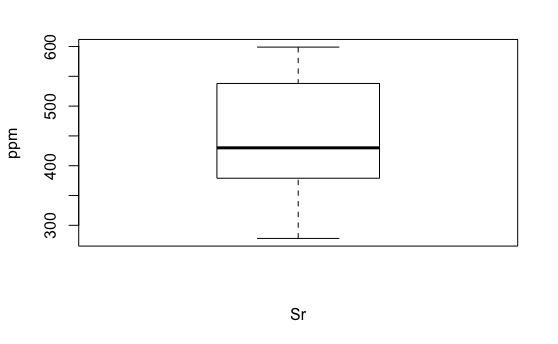

```r
boxplot(sazava[,"Sr"],xlab="Sr",ylab="ppm")
```

```r
summary(sazava[,"Sr"])
```

```
   Min. 1st Qu.  Median    Mean 3rd Qu.    Max.    NA's
  278.0   392.5   430.0   443.0   537.5   599.0       2
```

3. Plot all the possible combinations of binary diagrams(a scatter plot matrix) for the following oxides: SiO2, MgO, CaO, Na2O, K2O, and P2O5.

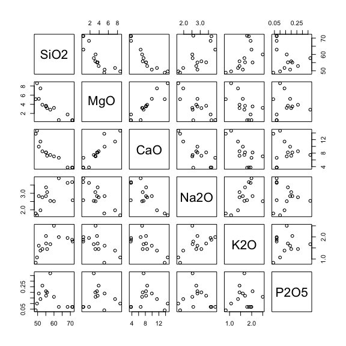

```r
oxides <- c("SiO2", "MgO", "CaO", "Na2O", "K2O", "P2O5")
pairs(sazava[,oxides])
```

## 2.4. Classification and Grouping - Using Factors

### Exercise 2.5. Using factors to deal with complex datasets I

1. For the Sázava dataset define a factor intrusion based on the specification given in the column ‘Intrusion’ that splits the suite into three groups: basic (quartz diorites to Amp gabbros of numerous smaller bodies), Sazava (Sázava intrusion proper: mainly Amp–Bt tonalites to quartz diorites) and Pozary (Požáry trondhjemite).

```r
sazava <- read.table("../Janousek_et_al_2015_modelling_Springer/Part_1/Code/Data/sazava.data", sep="\t")
intrusion <- factor(sazava[,"Intrusion"])
intrusion
```

```
 [1] Sazava Sazava Sazava Sazava Sazava basic  basic  basic  basic  basic
[11] Pozary Pozary Pozary Pozary
Levels: basic Pozary Sazava
```

2. Display all possible values (levels)of this factor.

```r
levels(intrusion)
```

```
[1] "basic"  "Pozary" "Sazava"
```

3. Using the factor intrusion, calculate the mean SiO2 contents for each of the rock groups in the Sazava dataset.

```r
tapply(sazava[,"SiO2"],intrusion,mean)
```

```
 basic Pozary Sazava
51.778 68.440 55.738
```

4. Analogously,calculate the mean concentrations of Ba.

```r
tapply(sazava[,"Ba"],intrusion,mean,na.rm=TRUE)
```

```
  basic  Pozary  Sazava
 676.25 1291.25  682.25
```

## Exercise 2.6. Using factors to deal with complex datasets II

1. Utilizing the function summary, calculate basic statistical parameters for SiO2 distribution in each of the rock groups of the Sázava suite (factor intrusion).

```r
sazava <- read.table("../Janousek_et_al_2015_modelling_Springer/Part_1/Code/Data/sazava.data", sep="\t")
intrusion <- factor(sazava[,"Intrusion"])
tapply(sazava[,"SiO2"],intrusion,summary)
```

```
$basic
   Min. 1st Qu.  Median    Mean 3rd Qu.    Max.
  48.84   49.63   51.72   51.78   52.90   55.80

$Pozary
   Min. 1st Qu.  Median    Mean 3rd Qu.    Max.
  62.95   66.96   69.69   68.44   71.17   71.42

$Sazava
   Min. 1st Qu.  Median    Mean 3rd Qu.    Max.
  50.72   55.09   55.17   55.74   57.73   59.98
```

2. What are the means for selected trace elements (Ba, Rb, Sr and Zr) in individual intrusions?

```r
trace <- c("Rb","Sr","Ba","Zr")
aggregate(sazava[,trace],list(Rock=intrusion),mean,na.rm=TRUE)
```

| Rock | Rb | Sr | Ba | Zr |
| --- | --- | --- | --- | --- |
| basic | 34.5 | 346.25 | 676.25 | 65.75 |
| Pozary | 59.5 | 460.75 | 1291.25 | 157.25 |
| Sazava | 60.5 | 522.00 | 682.25 | 61.00 |

3. Using the function by, print basic statistical summaries for major-element oxides in each of the rock groups.

```r
by(sazava[,7:17],list(Rock=intrusion),summary)
```

```
Rock: basic
      SiO2            TiO2           Al2O3            FeO
 Min.   :48.84   Min.   :0.340   Min.   :13.34   Min.   :2.740
 1st Qu.:49.63   1st Qu.:0.670   1st Qu.:14.17   1st Qu.:5.690
 Median :51.72   Median :0.760   Median :16.98   Median :6.220
 Mean   :51.78   Mean   :0.784   Mean   :16.87   Mean   :5.664
 3rd Qu.:52.90   3rd Qu.:0.800   3rd Qu.:18.23   3rd Qu.:6.430
 Max.   :55.80   Max.   :1.350   Max.   :21.64   Max.   :7.240
     Fe2O3           MnO             MgO             CaO
 Min.   :1.47   Min.   :0.130   Min.   :3.160   Min.   : 7.22
 1st Qu.:2.44   1st Qu.:0.160   1st Qu.:3.890   1st Qu.: 8.55
 Median :2.79   Median :0.160   Median :5.110   Median :11.44
 Mean   :2.64   Mean   :0.174   Mean   :5.644   Mean   :11.12
 3rd Qu.:3.22   3rd Qu.:0.170   3rd Qu.:7.470   3rd Qu.:13.75
 Max.   :3.28   Max.   :0.250   Max.   :8.590   Max.   :14.64
      Na2O           K2O             P2O5
 Min.   :1.67   Min.   :0.830   Min.   :0.040
 1st Qu.:1.78   1st Qu.:1.070   1st Qu.:0.100
 Median :1.97   Median :1.380   Median :0.140
 Mean   :2.25   Mean   :1.236   Mean   :0.148
 3rd Qu.:2.76   3rd Qu.:1.450   3rd Qu.:0.200
 Max.   :3.07   Max.   :1.450   Max.   :0.260
-------------------------------------------------------
Rock: Pozary
      SiO2            TiO2          Al2O3            FeO
 Min.   :62.95   Min.   :0.28   Min.   :15.04   Min.   :1.650
 1st Qu.:66.96   1st Qu.:0.28   1st Qu.:15.08   1st Qu.:2.002
 Median :69.69   Median :0.29   Median :15.19   Median :2.120
 Mean   :68.44   Mean   :0.29   Mean   :16.36   Mean   :2.075
 3rd Qu.:71.17   3rd Qu.:0.30   3rd Qu.:16.47   3rd Qu.:2.192
 Max.   :71.42   Max.   :0.30   Max.   :20.02   Max.   :2.410
     Fe2O3            MnO              MgO             CaO
 Min.   :0.380   Min.   :0.0400   Min.   :0.520   Min.   :3.670
 1st Qu.:0.395   1st Qu.:0.0475   1st Qu.:0.520   1st Qu.:3.730
 Median :0.435   Median :0.0500   Median :0.535   Median :3.755
 Mean   :0.480   Mean   :0.0500   Mean   :0.840   Mean   :4.447
 3rd Qu.:0.520   3rd Qu.:0.0525   3rd Qu.:0.855   3rd Qu.:4.473
 Max.   :0.670   Max.   :0.0600   Max.   :1.770   Max.   :6.610
      Na2O            K2O            P2O5
 Min.   :2.580   Min.   :1.79   Min.   :0.07
```

[output cut: 13 more lines]

```
 Max.   :59.98   Max.   :0.950   Max.   :18.82   Max.   :7.650
     Fe2O3            MnO             MgO            CaO
 Min.   :1.000   Min.   :0.120   Min.   :2.82   Min.   :7.04
 1st Qu.:1.350   1st Qu.:0.150   1st Qu.:3.21   1st Qu.:7.47
 Median :2.130   Median :0.160   Median :3.52   Median :8.20
 Mean   :1.866   Mean   :0.172   Mean   :3.68   Mean   :8.17
 3rd Qu.:2.190   3rd Qu.:0.190   3rd Qu.:3.67   3rd Qu.:8.22
 Max.   :2.660   Max.   :0.240   Max.   :5.18   Max.   :9.92
      Na2O            K2O             P2O5
 Min.   :2.520   Min.   :1.600   Min.   :0.16
 1st Qu.:2.540   1st Qu.:1.670   1st Qu.:0.17
 Median :2.830   Median :1.700   Median :0.19
 Mean   :2.816   Mean   :1.902   Mean   :0.22
 3rd Qu.:2.830   3rd Qu.:2.040   3rd Qu.:0.21
 Max.   :3.360   Max.   :2.500   Max.   :0.37
```